# Lab 3

```r
library(tidyverse)
bball = read.table("https://raw.githubusercontent.com/kbodwin/ShinyLabs/master/Datasets/cp_bball.csv", header = TRUE)
```

## The Dataset

```r
bball %>% tail()
```

```
##        Date     Team Team.Location Team.Score               Opponent
## 22  2/20/16 Cal Poly          Home         71   Cal State Northridge
## 23  2/25/16 Cal Poly          Home         77    Cal State Fullerton
## 24   3/3/16 Cal Poly          Away         62              UC-Irvine
## 25   3/5/16 Cal Poly          Away         50       UC-Santa Barbara
## 26 11/18/15 Cal Poly          Home         71 Cal State Monterey Bay
## 27 11/28/15 Cal Poly          Home         85        Antelope Valley
##    Opponent.Score Team.Result
## 22             75        Loss
## 23             78        Loss
## 24             72        Loss
## 25             69        Loss
## 26             62         Win
## 27             55         Win
```

The dataset has information about the Cal Poly basketball team from the 2015-2016 season. This includes info such as their opponents, points scored by both teams, game dates, their locations, results, and more.

## Is Cal Poly a worse than average team?

```r
bball %>% count(Team.Result)
```

```
## # A tibble: 2 x 2
##   Team.Result     n
##   <fct>       <int>
## 1 Loss           19
## 2 Win             8
```

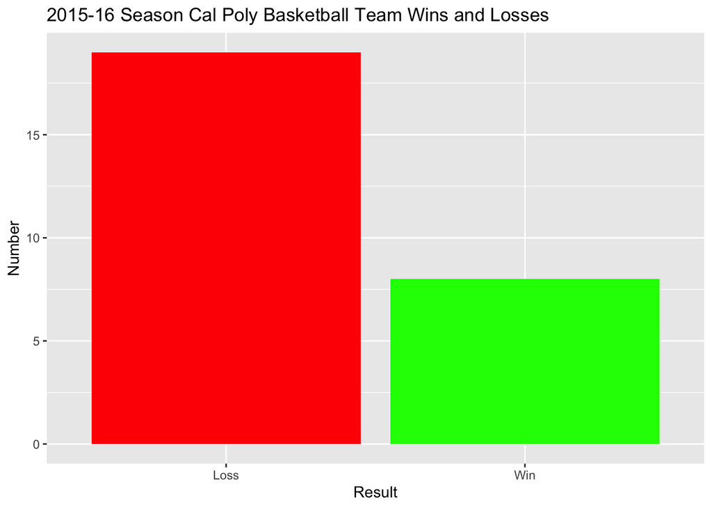

```r
ggplot(bball, aes(x = Team.Result)) +
  geom_bar(fill = c("red","green")) +
  ggtitle("2015-16 Season Cal Poly Basketball Team Wins and Losses") +
  xlab("Result") +
  ylab("Number")
```

```r
a = 8/27
paste("Win Percentage = ", a)
```

```
## [1] "Win Percentage =  0.296296296296296"
```

In the 2015-2016 season, Cal Poly won 8 games and lost 19 games. This means they won 29.63% of their games. Cal Poly is not an average team; they are a below average team since they won below significantly below than 50% of their games.